# **Aerofit Treadmill Dataset**

## **Business Problem**

The market research team at AeroFit wants to identify the characteristics of the target audience for each type of treadmill offered by the company, to provide a better recommendation of the treadmills to the new customers. The team decides to investigate whether there are differences across the product with respect to customer characteristics.

Perform descriptive analytics to create a customer profile for each AeroFit treadmill product by developing appropriate tables and charts. For each AeroFit treadmill product, construct two-way contingency tables and compute all conditional and marginal probabilities along with their insights/impact on the business.

Product Portfolio:

The KP281 is an entry-level treadmill that sells for $1,500.

The KP481 is for mid-level runners that sell for $1,750.

The KP781 treadmill is having advanced features that sell for $2,500.

## **Dataset**

The company collected the data on individuals who purchased a treadmill from the AeroFit stores during the prior three months. The dataset has the following features:

**Product Purchased**: KP281, KP481, or KP781

**Age**: Age of customer In years

**Gender**: Male/Female

**Education**: Years of Education Completed

**MaritalStatus**: Single or partnered

**Usage**: The average number of times the customer plans to use the treadmill each week.

**Income**: Annual income of the customer(in $)

**Fitness**: Self-rated fitness on a 1-to-5 scale, where 1 is the poor shape and 5 is the excellent shape.

**Miles**: The average number of miles the customer expects to walk/run each week

## **Characteristics Of Customers based on model:**

- Customers purchasing KP281 and KP481 are generally young adults with moderate fitness levels, moderate treadmill usage, and middle-income profiles, indicating these models cater to casual to moderately active users.
- In contrast, KP781 customers have significantly higher income, fitness levels, usage frequency, and miles run, suggesting this model targets serious runners and high-intensity fitness enthusiasts.
- Overall, income, fitness level, usage frequency, and miles run are the primary factors differentiating treadmill buyers, while age does not significantly influence product choice.

## Data Analysis

```python
import numpy as np
import pandas as pd
import seaborn as sns
import matplotlib.pyplot as plt
```

```python
df = pd.read_csv('aerofit_treadmill.csv')
```

```python
df.shape
```

```
(180, 9)
```

```python
# Basic Information about the dataset

df.info()
```

```
<class 'pandas.core.frame.DataFrame'>
RangeIndex: 180 entries, 0 to 179
Data columns (total 9 columns):
 #   Column         Non-Null Count  Dtype
---  ------         --------------  -----
 0   Product        180 non-null    object
 1   Age            180 non-null    int64
 2   Gender         180 non-null    object
 3   Education      180 non-null    int64
 4   MaritalStatus  180 non-null    object
 5   Usage          180 non-null    int64
 6   Fitness        180 non-null    int64
 7   Income         180 non-null    int64
 8   Miles          180 non-null    int64
dtypes: int64(6), object(3)
memory usage: 12.8+ KB
```

```python
# Description of the dataset

df.describe()
```

|  | Age | Education | Usage | Fitness | Income | Miles |
| --- | --- | --- | --- | --- | --- | --- |
| count | 180.000000 | 180.000000 | 180.000000 | 180.000000 | 180.000000 | 180.000000 |
| mean | 28.788889 | 15.572222 | 3.455556 | 3.311111 | 53719.577778 | 103.194444 |
| std | 6.943498 | 1.617055 | 1.084797 | 0.958869 | 16506.684226 | 51.863605 |
| min | 18.000000 | 12.000000 | 2.000000 | 1.000000 | 29562.000000 | 21.000000 |
| 25% | 24.000000 | 14.000000 | 3.000000 | 3.000000 | 44058.750000 | 66.000000 |
| 50% | 26.000000 | 16.000000 | 3.000000 | 3.000000 | 50596.500000 | 94.000000 |
| 75% | 33.000000 | 16.000000 | 4.000000 | 4.000000 | 58668.000000 | 114.750000 |
| max | 50.000000 | 21.000000 | 7.000000 | 5.000000 | 104581.000000 | 360.000000 |

```python
# General Understanding of the Dataset

df.head()
```

|  | Product | Age | Gender | Education | MaritalStatus | Usage | Fitness | Income | Miles |
| --- | --- | --- | --- | --- | --- | --- | --- | --- | --- |
| 0 | KP281 | 18 | Male | 14 | Single | 3 | 4 | 29562 | 112 |
| 1 | KP281 | 19 | Male | 15 | Single | 2 | 3 | 31836 | 75 |
| 2 | KP281 | 19 | Female | 14 | Partnered | 4 | 3 | 30699 | 66 |
| 3 | KP281 | 19 | Male | 12 | Single | 3 | 3 | 32973 | 85 |
| 4 | KP281 | 20 | Male | 13 | Partnered | 4 | 2 | 35247 | 47 |

```python
# Duplicated entries check

df.duplicated().sum()
```

```
np.int64(0)
```

```python
# Null values check

df.isnull().sum()
```

|  | 0 |
| --- | --- |
| Product | 0 |
| Age | 0 |
| Gender | 0 |
| Education | 0 |
| MaritalStatus | 0 |
| Usage | 0 |
| Fitness | 0 |
| Income | 0 |
| Miles | 0 |

**dtype:** int64

```python
cols = df.columns
for col in cols:
  print(col)
  print(df[col].unique())
```

```
Product
['KP281' 'KP481' 'KP781']
Age
[18 19 20 21 22 23 24 25 26 27 28 29 30 31 32 33 34 35 36 37 38 39 40 41
 43 44 46 47 50 45 48 42]
Gender
['Male' 'Female']
Education
[14 15 12 13 16 18 20 21]
MaritalStatus
['Single' 'Partnered']
Usage
[3 2 4 5 6 7]
Fitness
[4 3 2 1 5]
Income
[ 29562  31836  30699  32973  35247  37521  36384  38658  40932  34110
  39795  42069  44343  45480  46617  48891  53439  43206  52302  51165
  50028  54576  68220  55713  60261  67083  56850  59124  61398  57987
  64809  47754  65220  62535  48658  54781  48556  58516  53536  61006
  57271  52291  49801  62251  64741  70966  75946  74701  69721  83416
  88396  90886  92131  77191  52290  85906 103336  99601  89641  95866
 104581  95508]
Miles
[112  75  66  85  47 141 103  94 113  38 188  56 132 169  64  53 106  95
 212  42 127  74 170  21 120 200 140 100  80 160 180 240 150 300 280 260
 360]
```

The dataset has been checked for duplicates, null values and for datatypes. The dataset is clean.

```python
df.head(20)
```

|  | Product | Age | Gender | Education | MaritalStatus | Usage | Fitness | Income | Miles |
| --- | --- | --- | --- | --- | --- | --- | --- | --- | --- |
| 0 | KP281 | 18 | Male | 14 | Single | 3 | 4 | 29562 | 112 |
| 1 | KP281 | 19 | Male | 15 | Single | 2 | 3 | 31836 | 75 |
| 2 | KP281 | 19 | Female | 14 | Partnered | 4 | 3 | 30699 | 66 |
| 3 | KP281 | 19 | Male | 12 | Single | 3 | 3 | 32973 | 85 |
| 4 | KP281 | 20 | Male | 13 | Partnered | 4 | 2 | 35247 | 47 |
| 5 | KP281 | 20 | Female | 14 | Partnered | 3 | 3 | 32973 | 66 |
| 6 | KP281 | 21 | Female | 14 | Partnered | 3 | 3 | 35247 | 75 |
| 7 | KP281 | 21 | Male | 13 | Single | 3 | 3 | 32973 | 85 |
| 8 | KP281 | 21 | Male | 15 | Single | 5 | 4 | 35247 | 141 |
| 9 | KP281 | 21 | Female | 15 | Partnered | 2 | 3 | 37521 | 85 |
| 10 | KP281 | 22 | Male | 14 | Single | 3 | 3 | 36384 | 85 |
| 11 | KP281 | 22 | Female | 14 | Partnered | 3 | 2 | 35247 | 66 |
| 12 | KP281 | 22 | Female | 16 | Single | 4 | 3 | 36384 | 75 |
| 13 | KP281 | 22 | Female | 14 | Single | 3 | 3 | 35247 | 75 |
| 14 | KP281 | 23 | Male | 16 | Partnered | 3 | 1 | 38658 | 47 |
| 15 | KP281 | 23 | Male | 16 | Partnered | 3 | 3 | 40932 | 75 |
| 16 | KP281 | 23 | Female | 14 | Single | 2 | 3 | 34110 | 103 |
| 17 | KP281 | 23 | Male | 16 | Partnered | 4 | 3 | 39795 | 94 |
| 18 | KP281 | 23 | Female | 16 | Single | 4 | 3 | 38658 | 113 |
| 19 | KP281 | 23 | Female | 15 | Partnered | 2 | 2 | 34110 | 38 |

## Univariate Analysis

```python
# Lets check for outliers.

numerical_columns = df.select_dtypes(['int64', 'float64']).columns

categorical_columns = df.select_dtypes(exclude=['int64', 'float64']).columns
```

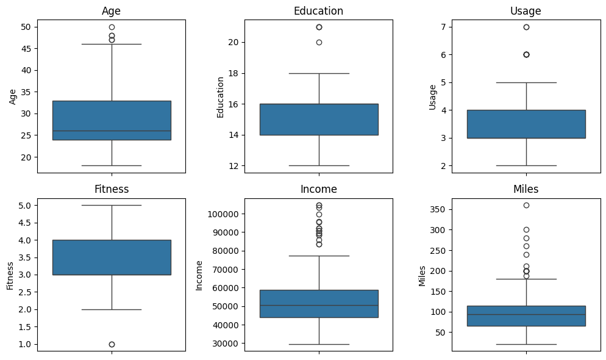

```python
import math

if len(numerical_columns) >= 3:
  n_cols = 3
else:
  n_cols = len(numerical_columns)


n_rows = math.ceil(len(numerical_columns)/n_cols)

fig, axes = plt.subplots(n_rows, n_cols, figsize=(10,6))

axes = axes.flatten()

for i, col in enumerate(numerical_columns):
  sns.boxplot(y=df[col], ax=axes[i])
  axes[i].set_title(col)

for j in range(i+1, len(axes)):
  fig.delaxes(axes[j])

plt.tight_layout()
plt.show()
```

## Inferences:

- There are some outliers in the columns like age, Education, Usage which can mean that there are some people are above the age 45 and some are very highly educated for nealy 20 years and more and some people feel that they will use the treadmill for 7 days of the week.
- As for the spread of the data we can see that:
  - Most of the people are from 20-45, but high density in in the range 23-33 years. The median is ~26 years. **This means that younger people ranging from 20 to 35 are most likely to buy a treadmill, we will confirm this in the histogram**
  - Oftenly People having 12-16 years of education (Likely the college graduates) buy the treadmill when compared to the rest of the people in the data.
  - For many people, the average usage times in a week are 4 or less.
- For the Income column, there are heavy outliers which can represent the high earning customers which can be better for the business. The average income of a buyer is around 50000. Most of the people earn ~80000 or less in the data. This demonstrated right-skewness in the data.

The majority of customers fall in the 25–35 age group, have college-level education, and use the treadmill 3–4 times per week, suggesting the core customer base consists of young working professionals focused on maintaining moderate fitness levels.

Now are the high earning customers are the one who are fitness enthusiasts ? Lets find out.

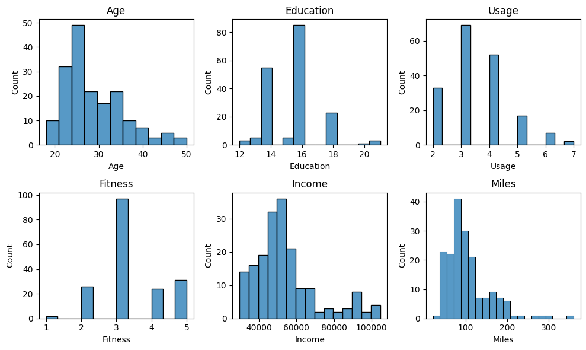

```python
n_cols = min(3, len(numerical_columns))
n_rows = math.ceil(len(numerical_columns)/n_cols)

fig, axes = plt.subplots(n_rows, n_cols, figsize=(10,6))

axes = axes.flatten()

for i, col in enumerate(numerical_columns):
  ax = sns.histplot(x=df[col], ax=axes[i])
  axes[i].set_title(col)

for j in range(i+1, len(numerical_columns)):
  fig.delaxes(axes[j])


plt.tight_layout()
plt.show()
```

Above demonstration supports our inferences from the boxplots.

```python
for col in categorical_columns:
  print(round(df[col].value_counts(normalize=True),2))
```

```
Product
KP281    0.44
KP481    0.33
KP781    0.22
Name: proportion, dtype: float64
Gender
Male      0.58
Female    0.42
Name: proportion, dtype: float64
MaritalStatus
Partnered    0.59
Single       0.41
Name: proportion, dtype: float64
```

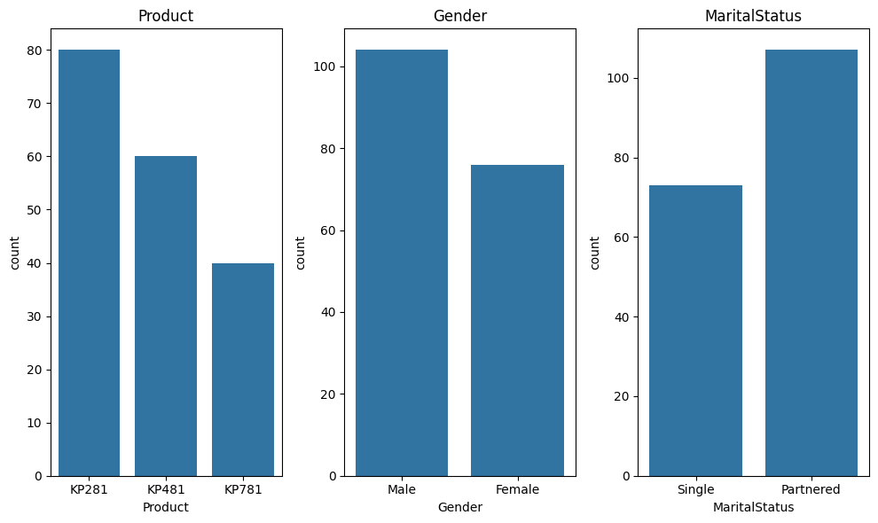

```python
n_cols = min(3, len(categorical_columns))
n_rows = math.ceil(len(categorical_columns)/ n_cols)

fig, axes = plt.subplots(n_rows, n_cols, figsize=(10,6))

for i, col in enumerate(categorical_columns):
  ax = sns.countplot(x=df[col], ax=axes[i])
  axes[i].set_title(col)

for j in range(i+1, len(categorical_columns)):
  fig.delaxes(axes[j])

plt.tight_layout()
plt.show()
```

**Inferences:**

- KP281 is sold in highest count maybe because it is the cheapest followed by KP481. KP781 is least prefered among all the three models probably because it is the most high tech and costly.
- Male customers made more than than 100 purchases which are more than female.
- Partnered Customer or married customer is more likely to buy the treadmill maybe for the fact that they care for their partner and themselves or they dont get enough time to go out so they prefer a home setup.

```python
df.head()
```

|  | Product | Age | Gender | Education | MaritalStatus | Usage | Fitness | Income | Miles |
| --- | --- | --- | --- | --- | --- | --- | --- | --- | --- |
| 0 | KP281 | 18 | Male | 14 | Single | 3 | 4 | 29562 | 112 |
| 1 | KP281 | 19 | Male | 15 | Single | 2 | 3 | 31836 | 75 |
| 2 | KP281 | 19 | Female | 14 | Partnered | 4 | 3 | 30699 | 66 |
| 3 | KP281 | 19 | Male | 12 | Single | 3 | 3 | 32973 | 85 |
| 4 | KP281 | 20 | Male | 13 | Partnered | 4 | 2 | 35247 | 47 |

## Bivariate Analysis

Now lets focus on the bivariate analysis and the relationships like:

- Numerical vs Numerical
- Categorical vs Numerical
- Categorical vs Categorical

```python
# Numerical vs Numerical
df[numerical_columns]
```

|  | Age | Education | Usage | Fitness | Income | Miles |
| --- | --- | --- | --- | --- | --- | --- |
| 0 | 18 | 14 | 3 | 4 | 29562 | 112 |
| 1 | 19 | 15 | 2 | 3 | 31836 | 75 |
| 2 | 19 | 14 | 4 | 3 | 30699 | 66 |
| 3 | 19 | 12 | 3 | 3 | 32973 | 85 |
| 4 | 20 | 13 | 4 | 2 | 35247 | 47 |
| ... | ... | ... | ... | ... | ... | ... |
| 175 | 40 | 21 | 6 | 5 | 83416 | 200 |
| 176 | 42 | 18 | 5 | 4 | 89641 | 200 |
| 177 | 45 | 16 | 5 | 5 | 90886 | 160 |
| 178 | 47 | 18 | 4 | 5 | 104581 | 120 |
| 179 | 48 | 18 | 4 | 5 | 95508 | 180 |

180 rows × 6 columns

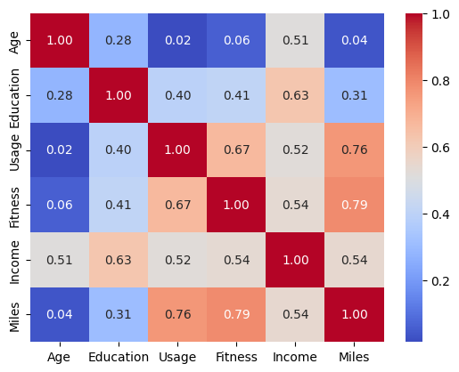

```python
sns.heatmap(df[numerical_columns].corr(), annot=True, fmt=".2f", cmap='coolwarm')
```

**Inferences**:

- Miles vs Fitness has highest correlation. That means Customers who rate themselves higher tend to run more times in the week. Can be potential customers who will purchase the KP781.
- Usage vs Miles is 0.76. Which has a straight meaning that customers who usage the treadmill more tends to run more number of miles.
- Customer with higher education are found out to have higher income. Which means more educated customer can represent higher purchasing power, making them more likely to purchase higher end model.
- Age is weakly correlated with most variables.

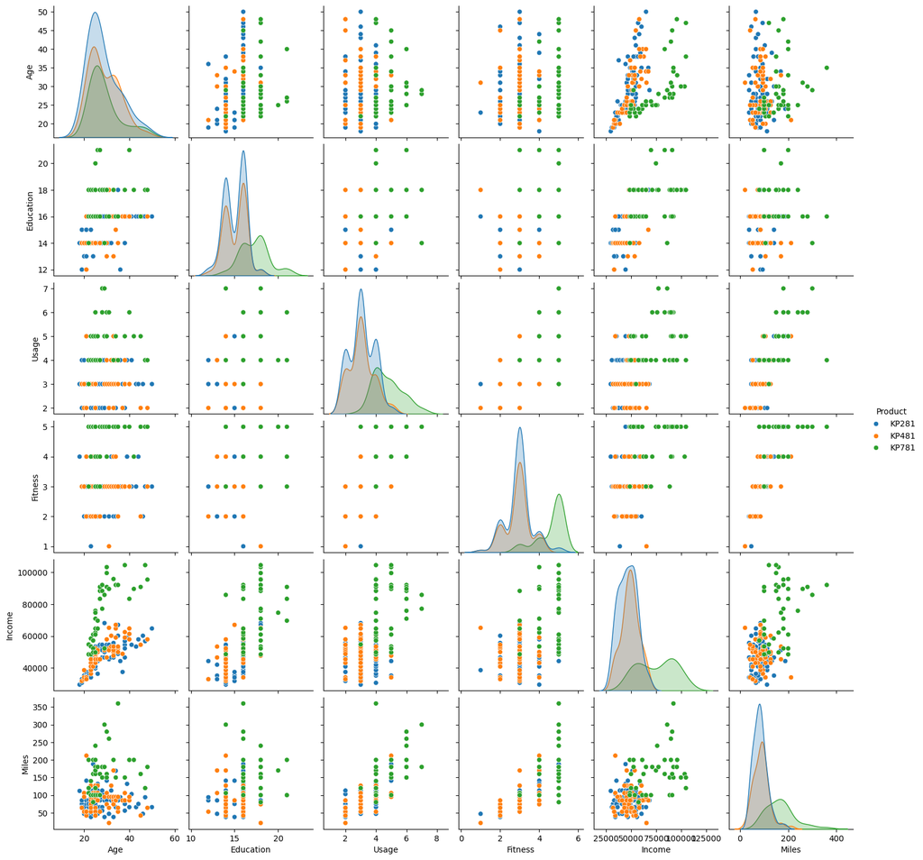

```python
plt.figure(figsize=(4,4))
sns.pairplot(df, hue='Product')
```

## Contingency Tables and Probabilities

```python
# Categorical Vs Categorical

df[categorical_columns]
```

|  | Product | Gender | MaritalStatus |
| --- | --- | --- | --- |
| 0 | KP281 | Male | Single |
| 1 | KP281 | Male | Single |
| 2 | KP281 | Female | Partnered |
| 3 | KP281 | Male | Single |
| 4 | KP281 | Male | Partnered |
| ... | ... | ... | ... |
| 175 | KP781 | Male | Single |
| 176 | KP781 | Male | Single |
| 177 | KP781 | Male | Single |
| 178 | KP781 | Male | Partnered |
| 179 | KP781 | Male | Partnered |

180 rows × 3 columns

```python
# Conditional Probabilities
pd.crosstab(df['Product'], df['Gender'], normalize='index')
```

| Gender Product | Female | Male |
| --- | --- | --- |
| KP281 | 0.500000 | 0.500000 |
| KP481 | 0.483333 | 0.516667 |
| KP781 | 0.175000 | 0.825000 |

The above table represents the conditional probability P(Gender | Product), meaning the probability of a customer being male or female given the treadmill model purchased.

Given that a customer purchased KP781, there is an 82.5% probability that the customer is male.

```python
# Probabilities in entire dataset
pd.crosstab(df['Product'], df['Gender'], normalize=True)
```

| Gender Product | Female | Male |
| --- | --- | --- |
| KP281 | 0.222222 | 0.222222 |
| KP481 | 0.161111 | 0.172222 |
| KP781 | 0.038889 | 0.183333 |

- KP281 is the most purchased treadmill, representing about 44% of total purchases.
- KP481 is the second most popular, representing about 33% of purchases.
- KP781 is the least purchased model, representing about 22% of purchases.
- The premium model KP781 is predominantly purchased by males, suggesting a gender preference.

```python
pd.crosstab(df['Product'], df['MaritalStatus'], normalize='index')
```

| MaritalStatus Product | Partnered | Single |
| --- | --- | --- |
| KP281 | 0.600 | 0.400 |
| KP481 | 0.600 | 0.400 |
| KP781 | 0.575 | 0.425 |

- It can be seen that, Married Customers are more likely to purchase a treadmill.

```python
pd.crosstab(df['Product'], df['MaritalStatus'], normalize=True)
```

| MaritalStatus Product | Partnered | Single |
| --- | --- | --- |
| KP281 | 0.266667 | 0.177778 |
| KP481 | 0.200000 | 0.133333 |
| KP781 | 0.127778 | 0.094444 |

```python
pd.crosstab(df['Gender'], df['MaritalStatus'], normalize='index')
```

| MaritalStatus Gender | Partnered | Single |
| --- | --- | --- |
| Female | 0.605263 | 0.394737 |
| Male | 0.586538 | 0.413462 |

**Inferences**:

- KP781 is prefered more by men. The other two models shows a gender balance between customers.
- For All the models, partnered customers are more who made the purchase.
- Male partnered buyers are the majority group overall, which can be key segment.

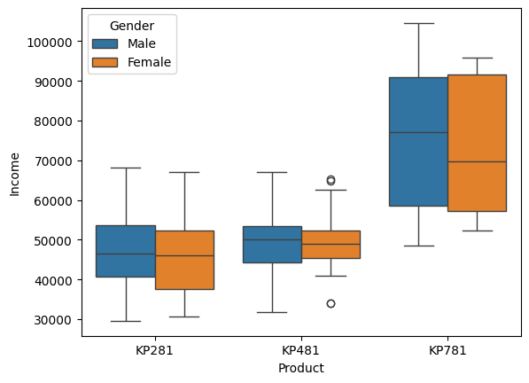

```python
# Categorical vs Numerical

sns.boxplot(x='Product', y='Income', hue='Gender', data=df)
```

People with high incomes tend to buy the more advanced model which is costly as well. But In the middle income side KP281 defeats KP481 in terms of preferences from the customers.

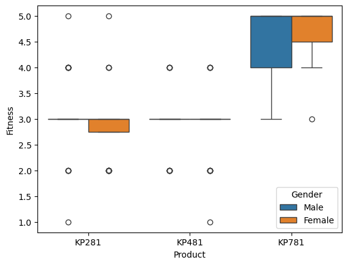

```python
sns.boxplot(data=df, x='Product', y='Fitness', hue='Gender')
```

We see here that customers who have higher fitness estimation prefer the KP781 which is the high tech version more. Other two remain balanced for normal fitness people as goal is to just be active.

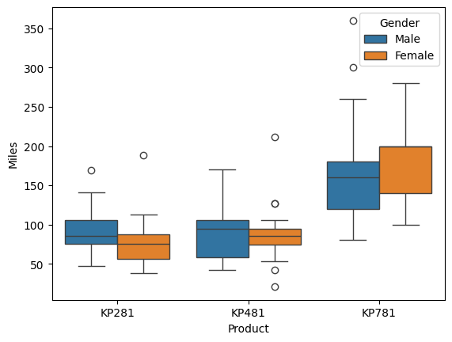

```python
sns.boxplot(data=df, x='Product', y='Miles', hue='Gender')
```

KP281 and KP481 are balanced Products and there is no distinction for both genders.

```python
df.groupby('Product').mean(numeric_only=True)
```

| Product | Age | Education | Usage | Fitness | Income | Miles |
| --- | --- | --- | --- | --- | --- | --- |
| KP281 | 28.55 | 15.037500 | 3.087500 | 2.9625 | 46418.025 | 82.787500 |
| KP481 | 28.90 | 15.116667 | 3.066667 | 2.9000 | 48973.650 | 87.933333 |
| KP781 | 29.10 | 17.325000 | 4.775000 | 4.6250 | 75441.575 | 166.900000 |

## Summary Table For Characteristics of Customers for Each Model:

**KP281 Customer Profile**

- Average age ~28.5 years
- Moderate fitness level
- Moderate treadmill usage (~3 times per week)
- Middle-income customers
- Runs around 83 miles per week

KP281 appears to be an entry-level treadmill suited for casual or moderate fitness users.

**KP481 Customer Profile**

- Similar age group (~29 years)
- Slightly higher income than KP281 customers
- Similar usage frequency
- Slightly higher miles run

KP481 appears to be a mid-range treadmill targeting moderately active users.

**KP781 Customer Profile**

- Similar age group (~29 years)
- Much higher education levels
- Significantly higher income
- Higher fitness level (~4.6)
- Much higher treadmill usage (~4.8 times per week)
- Runs nearly 167 miles per week

KP781 is clearly a premium treadmill preferred by serious fitness enthusiasts and high-income customers.

- Age does not differentiate treadmill buyers, but the following variables strongly do:
- Income
- Fitness level
- Usage frequency
- Miles run

These variables indicate training intensity and purchasing power, which are the main factors influencing treadmill choice.

## Insights

- KP281 serves as an entry-level treadmill for casual users.
- KP481 targets moderately active customers with slightly higher income.
- KP781 is clearly a premium treadmill preferred by high-income, high-fitness customers.
- Income, fitness level, usage frequency, and miles run are the primary differentiators of treadmill buyers.
- Age does not significantly influence treadmill selection.

Now, why does aerofit has KP481 when KP281 handles the general market and KP781 witholds the Premium Market. What is the need of KP481.

- Because KP481 is Likely a brighe product for customers who are progressing in their fitness, who are above the beginner level but not yet ready to purchase the premium model KP781. After a certain consistency, when they feel that they need a better challenge, then they will move to KP781. Similarly people from KP281 will improve to KP481. As the price is not that different and similar people are distributed in these two, moving up will be easy for them.
- The key factor that is influencing the treadmill model selection is the training intensity. Customers who run more miles tends to purchase the premium model whereas the moderate intensity people chose basic models.

## Recommendations:

- KP281 should be marketed as a beginner-friendly treadmill for general users.
- KP481 should be positioned as a mid-tier treadmill for moderately active individuals.
- KP781 should be marketed as a premium treadmill for serious runners and high-income fitness enthusiasts
- Aerofit's treadmill segmentation is driven more by fitness behavior and purchasing Power instead of factors like Age. So the company should focus marketing strategies on lifestyle and training intensity segments rather than age-based targeting.